# Analysis of Storm Affects on Population Health and Economy in USA

## Introduction

Storms and other severe weather events can cause both public health and economic problems for communities and municipalities. Many severe events can result in fatalities, injuries, and property damage, and preventing such outcomes to the extent possible is a key concern.

This project involves exploring the U.S. National Oceanic and Atmospheric Administration’s (NOAA) storm database. This database tracks characteristics of major storms and weather events in the United States, including when and where they occur, as well as estimates of any fatalities, injuries, and property damage.

## Data Processing

### Analysis

Sum aggregates of damages will provide a meaninful measure for our analysis.

Population health (HEALTHDAMAGES) for each event is obtained after cumulative sum of reported injuries and fatilities for each year between 1950 - 2011. Economic affect (DMGCASH) for each event is obtained after cumlative sum of crop and property damage and after applying appropiate multipler. The results are then sorted and top 25 events and their values are presented. Each storm data event is first grouped into a class and then the sums are obtained for each class.

### Loading

There is also some documentation of the database available: https://d396qusza40orc.cloudfront.net/repdata%2Fpeer2_doc%2Fpd01016005curr.pdf https://d396qusza40orc.cloudfront.net/repdata%2Fpeer2_doc%2FNCDC%20Storm%20Events-FAQ%20Page.pdf The data used for this analysis is available: https://d396qusza40orc.cloudfront.net/repdata%2Fdata%2FStormData.csv.bz2.

```r
#repdata-data-StormData.csv.bz2 is obtained from https://d396qusza40orc.cloudfront.net/repdata%2Fdata%2FStormData.csv.bz2
data <- read.csv(bzfile("repdata-data-StormData.csv.bz2"))
```

### Processing Health Affects

Get only health affects

```r
library(ggplot2)
library(data.table)
library(xtable)
health <- data[data$FATALITIES > 0 | data$INJURIES > 0,
                         c("EVTYPE", "INJURIES", "FATALITIES")]
health$EVTYPE2 <- as.factor(toupper(health$EVTYPE))
```

Calculate health affects (HEALTHDAMAGES)

```r
health$HEALTHDAMAGES <- health$FATALITIES + health$INJURIES;
health.sum <- tapply(health$HEALTHDAMAGES, health$EVTYPE2, sum)
health.sum <- data.frame(EVTYPE2=names(health.sum),
                            HEALTHDAMAGES=health.sum, row.names=NULL)
health.sum <- health.sum[order(health.sum$HEALTHDAMAGES,
                                     decreasing=TRUE), ]
xt <- xtable(health.sum)
print(xt, type="html", include.rownames=FALSE)
```

| EVTYPE2 | HEALTHDAMAGES |
| --- | --- |
| TORNADO | 96979.00 |
| EXCESSIVE HEAT | 8428.00 |
| TSTM WIND | 7461.00 |
| FLOOD | 7259.00 |
| LIGHTNING | 6046.00 |
| HEAT | 3037.00 |
| FLASH FLOOD | 2755.00 |
| ICE STORM | 2064.00 |
| THUNDERSTORM WIND | 1621.00 |
| WINTER STORM | 1527.00 |
| HIGH WIND | 1385.00 |
| HAIL | 1376.00 |
| HURRICANE/TYPHOON | 1339.00 |
| HEAVY SNOW | 1148.00 |
| WILDFIRE | 986.00 |
| THUNDERSTORM WINDS | 972.00 |
| BLIZZARD | 906.00 |
| FOG | 796.00 |
| RIP CURRENT | 600.00 |
| WILD/FOREST FIRE | 557.00 |
| HEAT WAVE | 551.00 |
| RIP CURRENTS | 501.00 |
| DUST STORM | 462.00 |
| WINTER WEATHER | 431.00 |
| TROPICAL STORM | 398.00 |
| AVALANCHE | 394.00 |
| EXTREME COLD | 393.00 |
| STRONG WIND | 383.00 |
| DENSE FOG | 360.00 |
| HEAVY RAIN | 349.00 |

[output cut: 175 more lines]

### Processing Economic Affects

Extract economic affects

```r
economic <- data[data$PROPDMG > 0 | data$CROPDMG > 0,
                         c("EVTYPE", "PROPDMG","PROPDMGEXP", "CROPDMG","CROPDMGEXP")]
economic$EVTYPE2 <- as.factor(toupper(economic$EVTYPE))
```

Calculate economic damages (DMGCASH).

```r
economic$PROPDMGEXP <- as.factor(toupper(as.character(economic$PROPDMGEXP)))
economic$CROPDMGEXP <- as.factor(toupper(as.character(economic$CROPDMGEXP)))

dvals <- unique(union(economic$PROPDMGEXP, economic$CROPDMGEXP))
DMGEXP <- numeric(18)
names(DMGEXP) <- dvals
DMGEXP[names(DMGEXP) %in% c("", "+", "-", "?")] <- 0
DMGEXP["H"] <- 2
DMGEXP["K"] <- 3
DMGEXP["M"] <- 6
DMGEXP["B"] <- 9

economic$PROPDMGCASH <- economic$PROPDMG * (10 ^ DMGEXP[economic$PROPDMGEXP])
economic$CROPDMGCASH <- economic$CROPDMG * (10 ^ DMGEXP[economic$CROPDMGEXP])
economic$DMGCASH <- economic$CROPDMGCASH + economic$PROPDMGCASH
#sum(is.na(economic$DMGCASH))
economic.sum <- tapply(economic$DMGCASH, economic$EVTYPE2, sum)
economic.sum <- data.frame(EVTYPE2=names(economic.sum),
                          DMGCASH=economic.sum, row.names=NULL)
economic.sum <- economic.sum[order(economic.sum$DMGCASH, decreasing=TRUE), ]
xt <- xtable(economic.sum)
print(xt, type="html", include.rownames=FALSE)
```

| EVTYPE2 | DMGCASH |
| --- | --- |
| TORNADO | 220003315053.68 |
| THUNDERSTORM WINDS | 80000675075.11 |
| HIGH WIND | 20015341979.77 |
| HAIL | 20001328209.66 |
| BREAKUP FLOODING | 20000000000.00 |
| HIGH WINDS | 15000060366.60 |
| FLOODING/HEAVY RAIN | 2000000000.00 |
| FLASH FLOOD | 1812850.05 |
| TSTM WIND | 1445198.21 |
| FLOOD | 1074969.36 |
| THUNDERSTORM WIND | 945633.62 |
| LIGHTNING | 609929.39 |
| WINTER STORM | 134699.58 |
| HEAVY SNOW | 124417.71 |
| WILDFIRE | 88823.54 |
| ICE STORM | 67689.62 |
| STRONG WIND | 64628.71 |
| HEAVY RAIN | 61964.94 |
| TROPICAL STORM | 54322.80 |
| WILD/FOREST FIRE | 43534.49 |
| DROUGHT | 37997.67 |
| FLASH FLOODING | 37619.20 |
| URBAN/SML STREAM FLD | 28845.74 |
| BLIZZARD | 25490.48 |
| THUNDERSTORM WINDS HAIL | 24730.00 |
| HURRICANE | 20852.99 |
| FLOOD/FLASH FLOOD | 20580.95 |
| STORM SURGE | 19398.49 |
| LANDSLIDE | 18998.94 |
| RIVER FLOOD | 17345.70 |

[output cut: 367 more lines]

### Processing Event Class Affects

Make groups by events.

```r
groups <- function (sd) {
    heat            <- grep("HEAT|HYPERTHERMIA", sd$EVTYPE2, ignore.case=TRUE)
    fire            <- grep("FIRE", sd$EVTYPE2, ignore.case=TRUE)
    drought         <- grep("DROUGHT", sd$EVTYPE2, ignore.case=TRUE)
    coastal         <- grep("CURRENT|SURF|SEAS|WAVE|MARINE", sd$EVTYPE2, ignore.case=TRUE)
    lightning       <- grep("LIGHTNING", sd$EVTYPE2, ignore.case=TRUE)
    rain            <- grep("RAIN|LANDSLIDE|MUDSLIDE|AVALANCH?E", sd$EVTYPE2, ignore.case=TRUE)
    flood           <- grep("FLOOD|TSUNAMI|WATER|FLD", sd$EVTYPE2, ignore.case=TRUE)
    fog             <- grep("FOG", sd$EVTYPE2, ignore.case=TRUE)
    snow.cold       <- grep("SNOW|COLD|HYPOTHERMIA|WINTER|HAIL|BLIZZARD|ICE|ICY|FREEZ|FROST|GLAZE|WINTRY",
                            sd$EVTYPE2, ignore.case=TRUE)
    blizzard        <- grep("BLIZZARD", sd$EVTYPE2, ignore.case=TRUE)
    tornado         <- grep("TORNADO", sd$EVTYPE2, ignore.case=TRUE)
    thunderstorm    <- grep("THUNDERSTORM|TSTM", sd$EVTYPE2, ignore.case=TRUE)
    hurricane       <- setdiff(grep("HURRICANE|TYPHOON", sd$EVTYPE2,
                                    ignore.case=TRUE), thunderstorm)
    storm           <- setdiff(grep("STORM", sd$EVTYPE2, ignore.case=TRUE),
                               union(thunderstorm, c(blizzard, hurricane)))
    wind            <- setdiff(grep("WIND", sd$EVTYPE2, ignore.case=TRUE), thunderstorm)
    accounted <- unique(c(tornado, heat, snow.cold, drought, flood, lightning, fire, rain, fog, coastal,
                          thunderstorm, wind, hurricane, blizzard, storm))
    others <- setdiff(1:nrow(sd), accounted)

    groups <- data.frame()
    groups <- rbind(groups, data.frame(group="TORNADO", EVTYPE2=unique(sd[tornado, c("EVTYPE2")])))
    groups <- rbind(groups, data.frame(group="HEAT", EVTYPE2=unique(sd[heat, c("EVTYPE2")])))
    groups <- rbind(groups, data.frame(group="SNOW/COLD", EVTYPE2=unique(sd[snow.cold, c("EVTYPE2")])))
    groups <- rbind(groups, data.frame(group="DROUGHT", EVTYPE2=unique(sd[drought, c("EVTYPE2")])))
    groups <- rbind(groups, data.frame(group="FLOOD", EVTYPE2=unique(sd[flood, c("EVTYPE2")])))
    groups <- rbind(groups, data.frame(group="LIGHTNING", EVTYPE2=unique(sd[lightning, c("EVTYPE2")])))
    groups <- rbind(groups, data.frame(group="FIRE", EVTYPE2=unique(sd[fire, c("EVTYPE2")])))
    groups <- rbind(groups, data.frame(group="RAIN", EVTYPE2=unique(sd[rain, c("EVTYPE2")])))
    groups <- rbind(groups, data.frame(group="FOG", EVTYPE2=unique(sd[fog, c("EVTYPE2")])))
    groups <- rbind(groups, data.frame(group="COASTAL", EVTYPE2=unique(sd[coastal, c("EVTYPE2")])))
    groups <- rbind(groups, data.frame(group="THUNDERSTORM",
                                       EVTYPE2=unique(sd[thunderstorm, c("EVTYPE2")])))
    groups <- rbind(groups, data.frame(group="WIND", EVTYPE2=unique(sd[wind, c("EVTYPE2")])))
    groups <- rbind(groups, data.frame(group="HURRICANE", EVTYPE2=unique(sd[hurricane, c("EVTYPE2")])))
    groups <- rbind(groups, data.frame(group="BLIZZARD", EVTYPE2=unique(sd[blizzard, c("EVTYPE2")])))
    groups <- rbind(groups, data.frame(group="OTHER STORMS", EVTYPE2=unique(sd[storm, c("EVTYPE2")])))
    groups <- rbind(groups, data.frame(group="OTHER", EVTYPE2=unique(sd[others, c("EVTYPE2")])))
    groups
}
```

Calculate health affects by storm event classes

```r
health.grp <- groups(health)
health.mrg <- merge(health.sum, health.grp,
                       by.x="EVTYPE2", by.y="EVTYPE2",
                       all.x=TRUE, all.y=FALSE)

health.mrg.sum <- tapply(health.mrg$HEALTHDAMAGES, health.mrg$group, sum)
health.mrg.sum <- data.frame(GROUP=names(health.mrg.sum),
                            HEALTHDAMAGES=health.mrg.sum, row.names=NULL)
xt <- xtable(health.mrg.sum)
print(xt, type="html", include.rownames=FALSE)
```

| GROUP | HEALTHDAMAGES |
| --- | --- |
| TORNADO | 97068.00 |
| HEAT | 12363.00 |
| SNOW/COLD | 9327.00 |
| DROUGHT | 25.00 |
| FLOOD | 10480.00 |
| LIGHTNING | 6049.00 |
| FIRE | 1698.00 |
| RAIN | 914.00 |
| FOG | 1158.00 |
| COASTAL | 2315.00 |
| THUNDERSTORM | 10298.00 |
| WIND | 2692.00 |
| HURRICANE | 1468.00 |
| BLIZZARD | 907.00 |
| OTHER STORMS | 4636.00 |
| OTHER | 125.00 |

Calculate economic affects by storm event classes

```r
economic.grp <- groups(economic)
economic.mrg <- merge(economic.sum, economic.grp,
                       by.x="EVTYPE2", by.y="EVTYPE2",
                       all.x=TRUE, all.y=FALSE)

economic.mrg.sum <- tapply(economic.mrg$DMGCASH, economic.mrg$group, sum)
economic.mrg.sum <- data.frame(GROUP=names(economic.mrg.sum),
                              DMGCASH=economic.mrg.sum, row.names=NULL)
xt <- xtable(economic.mrg.sum)
print(xt, type="html", include.rownames=FALSE)
```

| GROUP | DMGCASH |
| --- | --- |
| TORNADO | 220003318555.78 |
| HEAT | 4706.04 |
| SNOW/COLD | 20001828422.38 |
| DROUGHT | 38253.45 |
| FLOOD | 22003072590.57 |
| LIGHTNING | 610292.89 |
| FIRE | 134789.03 |
| RAIN | 2000093457.15 |
| FOG | 17259.26 |
| COASTAL | 12972.51 |
| THUNDERSTORM | 80003113210.84 |
| WIND | 35015487311.30 |
| HURRICANE | 36824.44 |
| BLIZZARD | 26195.48 |
| OTHER STORMS | 296656.54 |
| OTHER | 12707.58 |

## Results

### Health Affects

Show top health affects

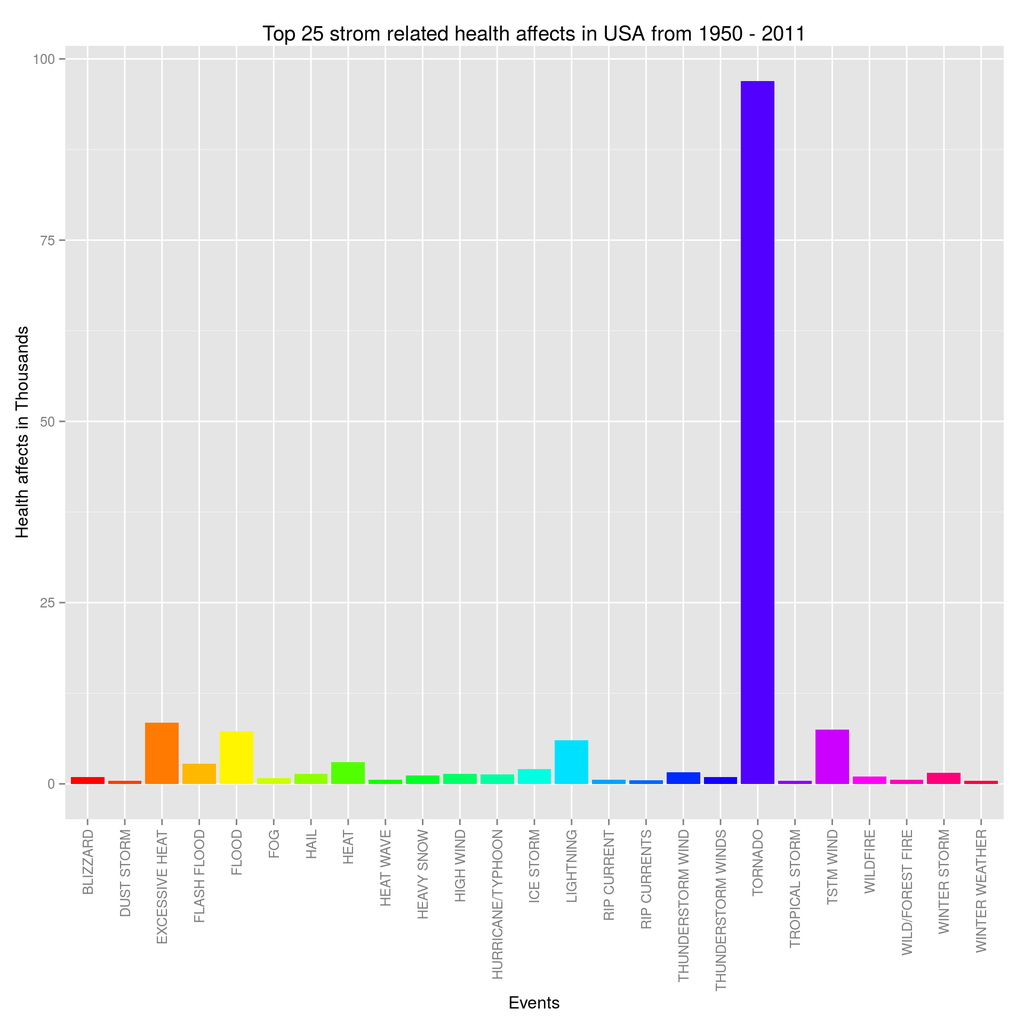

```r
health.sum.top <- head(health.sum, n=25)
health.sum.top$HEALTHDAMAGES <- health.sum.top$HEALTHDAMAGES / 1000

sdh.gp <- ggplot(health.sum.top, aes(x=EVTYPE2, y=HEALTHDAMAGES)) +
    xlab("Events") +
    ylab("Health affects in Thousands") +
    ggtitle(paste("Top", nrow(health.sum.top),
                  "strom related health affects in USA from 1950 - 2011")) +
    geom_bar(stat="identity", fill=rainbow(n=length(health.sum.top$EVTYPE2))) +
    theme(axis.text.x = element_text(angle = 90, hjust = 1, vjust=0.5))

sdh.gp
```

### Economic Affects

Show top economic affects

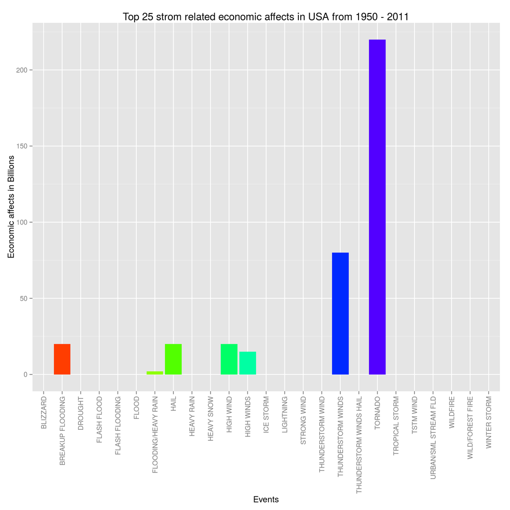

```r
economic.sum.top <- head(economic.sum, n=25)
economic.sum.top$DMGCASH <- economic.sum.top$DMGCASH / (10^9)

sde.gp <- ggplot(economic.sum.top, aes(x=EVTYPE2, y=DMGCASH)) +
    xlab("Events") +
    ylab("Economic affects in Billions") +
    ggtitle(paste("Top", nrow(economic.sum.top),
                  "strom related economic affects in USA from 1950 - 2011")) +
    geom_bar(stat="identity", fill=rainbow(n=length(economic.sum.top$EVTYPE2))) +
    theme(axis.text.x = element_text(angle = 90, hjust = 1, vjust=0.5))

sde.gp
```

### Event Class Affects

We use multiplot function, which is obtained from http://www.cookbook-r.com/Graphs/Multiple_graphs_on_one_page_(ggplot2)/

Show health and economic affects by storm event classes

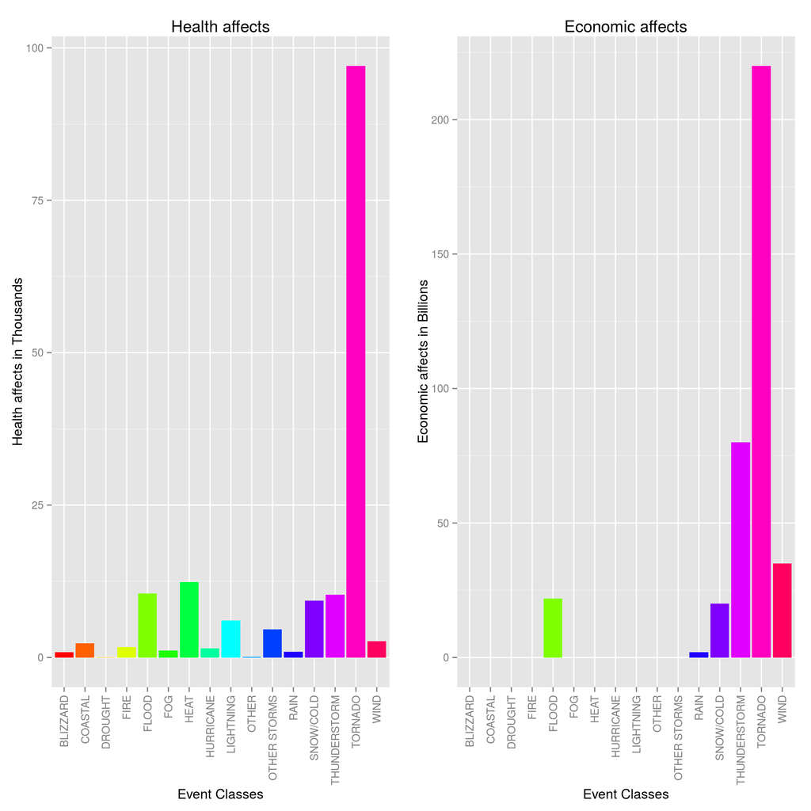

```r
health.mrg.sum$HEALTHDAMAGES <- health.mrg.sum$HEALTHDAMAGES / 1000
economic.mrg.sum$DMGCASH <- economic.mrg.sum$DMGCASH / (10^9)

sdh.grp.gp <- ggplot(health.mrg.sum, aes(x=GROUP, y=HEALTHDAMAGES)) +
    xlab("Event Classes") +
    ylab("Health affects in Thousands") +
    ggtitle("Health affects") +
    geom_bar(stat="identity", fill=rainbow(n=length(health.mrg.sum$GROUP))) +
    theme(axis.text.x = element_text(angle = 90, hjust = 1, vjust=0.5))

sde.grp.gp <- ggplot(economic.mrg.sum, aes(x=GROUP, y=DMGCASH)) +
    xlab("Event Classes") +
    ylab("Economic affects in Billions") +
    ggtitle("Economic affects") +
    geom_bar(stat="identity", fill=rainbow(n=length(economic.mrg.sum$GROUP))) +
    theme(axis.text.x = element_text(angle = 90, hjust = 1, vjust=0.5))

multiplot(sdh.grp.gp, sde.grp.gp, cols=2)
```

## Conclusion

This paper presents the types of storm related events that are responsible for most negative affects in USA from 1950 to 2011.